# Week04_Monday slides

## Week 04 Monday

Sept 16, 2024

## Announcements

2. A05 Lit review is released; due Oct 11. First **intermediate** deadline is **Wednesday 9/18/2024**
3. A04 has been released, due **Wednesday, 9/25/2024**

## Goals

1. Romi forward motion model construction (45 minutes)
2. Sensor calibration discussion (if time)
3. Work time for A04 (30 minutes)

## Model Construction

How are our elements arranged in an equivalent circuit?

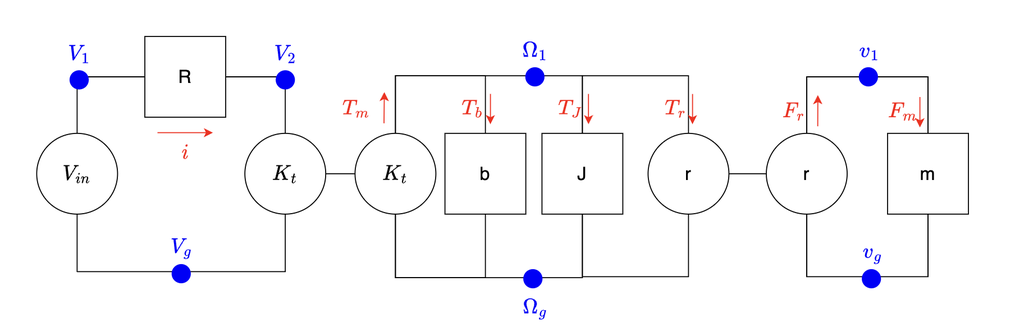

## Model Construction

What are the elemental, loop and node equations for this circuit?

## Model Construction

What are the elemental, loop and node equations for this circuit?

**Nodes** \begin{equation} i = i \end{equation} \begin{equation} T_m = T_b+T_J+T_r \end{equation} \begin{equation} F_r=F_m \end{equation}

**Loops** \begin{equation} V_{1g} = V_{12}+V_{2g} \end{equation}

**Elements** \begin{equation} V_{12}=iR \end{equation} \begin{equation} k_t i = T_m \end{equation} \begin{equation} k_t \Omega_{1g} = V_{2g} \end{equation} \begin{equation} T_b = b\Omega_{1g} \end{equation} \begin{equation} T_J = J\dot{\Omega}_{1g} \end{equation} \begin{equation} T_r = rF_r \end{equation} \begin{equation} v_{1g} = r\Omega_{1g} \end{equation} \begin{equation} F_m = m\dot{v}_{1g} \end{equation}

## Model Construction

Let's work through the algebra!

## Final model for Romi forward motion

\begin{equation} \dot{v} = \frac{1}{\frac{J}{r} + mr}\left( \frac{k_t}{R} V_{in} - \left(\frac{k_t^2}{R r} + \frac{b}{r} \right)v \right) \end{equation}

Don't forget to confirm units and signs (internal validity!!)

## How will we "fit" unknown parameters in this model so we can use it?

Some are available by measuring (wheel radius) and/or looking up parameters from the manufacturer's website

[figure not shown]

## How will we "fit" unknown parameters in this model so we can use it?

### We will use the *data* you collected! We can infer a couple of key things from the data.

- *Steady state behavior* (what happens once everything stops changing)
- *Transient behavior* (how the system reaches steady state)

## What did your Romi data look like for forward speed?

This is fictitious data... yours may be different!!

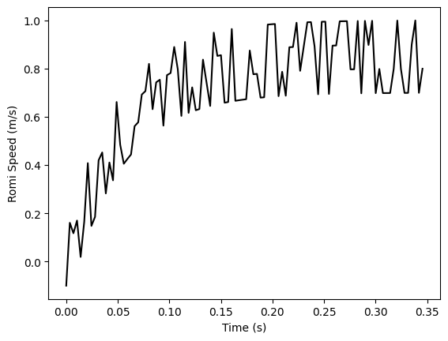

## How can we characterize a first-order response *numerically?*

## How can we characterize a first-order response's *transient behavior?*

## How can we characterize a first-order response's *transient behavior?*

Given a linear differential equation of the form $a_1\dot{y} + a_0y = b_0U$, we can use the *time constant* to characterize its **transient behavior.**

### Time Constant

- For a first order system, the system's single eigenvalue is $p=-\frac{a_0}{a_1}$.
- We define the time constant to be $\tau = \frac{a_1}{a_0} = -\frac{1}{p}$ **WHY?** When $t = \tau$, then the differential equation's **homogeneous** solution is \begin{equation} y_h(t) = y_0e^{-\frac{t}{\tau}} = y_oe^{-1} = 0.367879y_0 \end{equation}

This means that if $y(\tau) = 0.368 y_0$, then approximately 63.2% of the **change** from $t_0$ to $t_{ss}$ has occurred when $t=\tau$. For step responses, this means that the time constant can be pulled off of a plot by finding the time $\tau$ at which $y(t) = 0.632(y_{ss}-y_0)$.

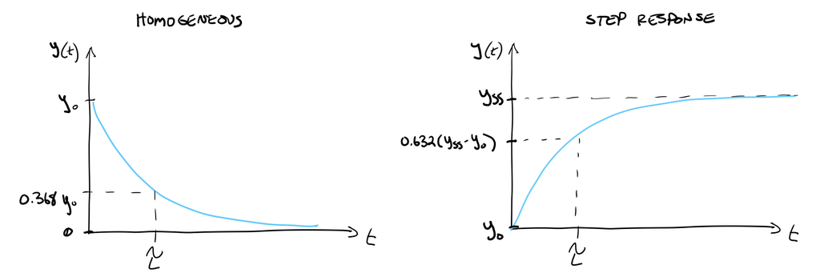

## How can we characterize a first-order response's *steady state* behavior?

## How can we characterize a first-order response's *steady state* behavior?

### Steady State Gain $\equiv \frac{\Delta y_{ss}}{\Delta U_{ss}}$

Given a first-order linear differential equation of the form $a_1\dot{y} + a_0y = b_0U$, setting $\dot{y}=0$ to indicate *steady state*, and solving for the change in our output at steady state yields

$$\Delta y_{ss} = y_{ss}-y_0 = \left(U_{ss} - U_0\right)\frac{b_0}{a_0}$$

This allows us to write an equation for "steady state gain" using the first-order differential equation's $a_0$ and $b_0$ terms.

$$K_{ss} = \frac{y_{ss}-y_0}{U-U_0} = \frac{\Delta y_{ss}}{\Delta u_{ss}} = \frac{b_0}{a_0} $$

## Solving for $\tau$ and $K_{ss}$ for your Romi data will allow you to compare these numbers with your model to solve for unknown parameters!

This will be your challenge for Assignment 6 (upcoming).